# ICD_codigo1

Project (Group X)

Marta Duarte nº202008344 (33%)

Miguel Gonçalves nº202107127 (33%)

Rodrigo Couto nº202104696 (33%)

# Introduction

The customer.csv is a database from US customers. The main goal of the project is to create a machine learning model to predict if a customer has or not a health insurance based on the given features.

### Imports

This are the necessary libraries:

```python
import pandas as pd
import numpy as np
import matplotlib.pyplot as plt
import seaborn as sns
import pickle
from collections import Counter
from sklearn.preprocessing import MinMaxScaler, StandardScaler
from sklearn.preprocessing import LabelEncoder
from sklearn.model_selection import train_test_split, KFold, StratifiedKFold, learning_curve, RandomizedSearchCV, cross_val_score, cross_val_predict, GridSearchCV
from sklearn.linear_model import LogisticRegression
from sklearn.ensemble import RandomForestClassifier, StackingClassifier
from sklearn.neighbors import KNeighborsClassifier
from sklearn.svm import SVC
from sklearn.pipeline import Pipeline
from sklearn.tree import DecisionTreeClassifier, plot_tree
from sklearn.metrics import accuracy_score, confusion_matrix, classification_report, roc_auc_score, roc_curve, recall_score, make_scorer
from imblearn.over_sampling import SMOTE
from imblearn.pipeline import Pipeline
import warnings
warnings.filterwarnings("ignore")
```

We will begin by creating a dataframe from the given dataset and then use describe() to gain a general understanding of the dataset.

```python
df = pd.read_csv("/content/sample_data/customer.csv", sep=",")
df.head()

display(df.describe())
df.shape
```

|  | Unnamed: 0 | income | num_vehicles | age | code_column | gas_usage | rooms |
| --- | --- | --- | --- | --- | --- | --- | --- |
| count | 72458.000000 | 7.245800e+04 | 70772.000000 | 72458.000000 | 72458.000000 | 70772.000000 | 72458.000000 |
| mean | 49910.637556 | 4.188143e+04 | 2.066820 | 49.208893 | 3285.523572 | 41.230501 | 3.494549 |
| std | 28772.082702 | 5.827460e+04 | 1.170076 | 18.090035 | 2661.775225 | 63.149323 | 1.706537 |
| min | 7.000000 | -6.900000e+03 | 0.000000 | 0.000000 | 131.000000 | 1.000000 | 1.000000 |
| 25% | 24911.250000 | 1.070000e+04 | 1.000000 | 34.000000 | 1305.000000 | 3.000000 | 2.000000 |
| 50% | 49838.000000 | 2.640000e+04 | 2.000000 | 48.000000 | 2269.000000 | 10.000000 | 3.000000 |
| 75% | 74786.750000 | 5.200000e+04 | 3.000000 | 62.000000 | 4979.000000 | 60.000000 | 5.000000 |
| max | 100000.000000 | 1.257000e+06 | 6.000000 | 120.000000 | 8962.000000 | 570.000000 | 6.000000 |

```
(72458, 15)
```

# Data preprocessing

```python
df.columns
```

```
Index(['Unnamed: 0', 'custid', 'sex', 'is_employed', 'income',
       'marital_status', 'health_ins', 'housing_type', 'num_vehicles', 'age',
       'state_of_res', 'code_column', 'gas_usage', 'rooms', 'recent_move_b'],
      dtype='object')
```

Inicial analysis of the variables:

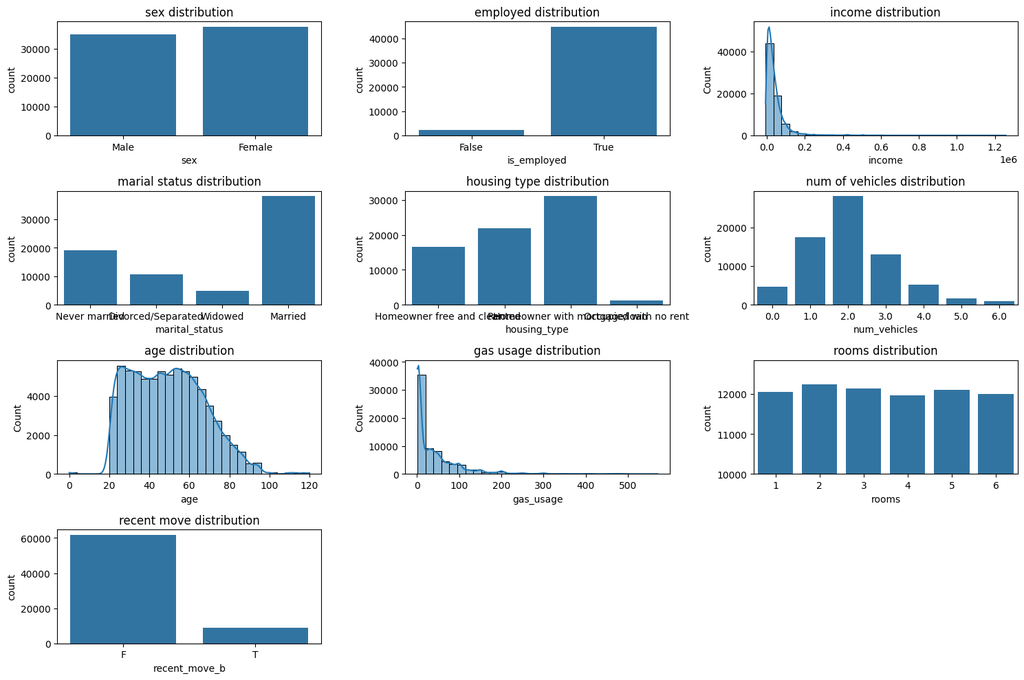

```python
plt.figure(figsize=(15, 10))

plt.subplot(4, 3, 1)
sns.countplot(data=df, x='sex')
plt.title('sex distribution')

plt.subplot(4, 3, 2)
sns.countplot(data=df, x='is_employed')
plt.title('employed distribution')

plt.subplot(4, 3, 3)
sns.histplot(data=df, x='income', bins=30, kde=True)
plt.title('income distribution')

plt.subplot(4, 3, 4)
sns.countplot(data=df, x='marital_status')
plt.title('marial status distribution')

plt.subplot(4, 3, 5)
sns.countplot(data=df, x='housing_type')
plt.title('housing type distribution')

plt.subplot(4, 3, 6)
sns.countplot(data=df, x='num_vehicles')
plt.title('num of vehicles distribution')

plt.subplot(4, 3, 7)
sns.histplot(data=df, x='age', bins=30, kde=True)
plt.title('age distribution')

plt.subplot(4, 3, 8)
sns.histplot(data=df, x='gas_usage', bins=30, kde=True)
plt.title('gas usage distribution')

plt.subplot(4, 3, 9)
sns.countplot(data=df, x='rooms')
plt.title('rooms distribution')
plt.ylim(10000, plt.ylim()[1])

plt.subplot(4, 3, 10)
sns.countplot(data=df, x='recent_move_b')
plt.title('recent move distribution')

plt.tight_layout()
plt.show()
```

This plot shows us how skewed gas_usage and income are. The other categorical plots aren't relevant.

Removing null values:

```python
pd.set_option('display.max_rows', None)
for column in df.columns:
    null_count = df[column].isnull().sum()
    print(f"{column}: {null_count} null values")

num_linhas_age_0 = df[df['age'] == 0].shape[0]
print("Number of lines with age equal to 0:", num_linhas_age_0)
```

```
Unnamed: 0: 0 null values
custid: 0 null values
sex: 0 null values
is_employed: 25515 null values
income: 0 null values
marital_status: 0 null values
health_ins: 0 null values
housing_type: 1686 null values
num_vehicles: 1686 null values
age: 0 null values
state_of_res: 0 null values
code_column: 0 null values
gas_usage: 1686 null values
rooms: 0 null values
recent_move_b: 1687 null values
Number of lines with age equal to 0: 77
```

To handle 'is_employed' we are going to transform it with one-hot-encoding, since we can't remove it's nulls values because they represent retired people.

```python
df_encoded = pd.get_dummies(df, columns=['is_employed'], drop_first=False)
df_encoded.head()
```

|  | Unnamed: 0 | custid | sex | income | marital_status | health_ins | housing_type | num_vehicles | age | state_of_res | code_column | gas_usage | rooms | recent_move_b | is_employed_False | is_employed_True |
| --- | --- | --- | --- | --- | --- | --- | --- | --- | --- | --- | --- | --- | --- | --- | --- | --- |
| 0 | 7 | 000006646_03 | Male | 22000.0 | Never married | True | Homeowner free and clear | 0.0 | 24 | Alabama | 1047 | 210.0 | 3 | F | False | True |
| 1 | 8 | 000007827_01 | Female | 23200.0 | Divorced/Separated | True | Rented | 0.0 | 82 | Alabama | 1047 | 3.0 | 6 | T | False | False |
| 2 | 9 | 000008359_04 | Female | 21000.0 | Never married | True | Homeowner with mortgage/loan | 2.0 | 31 | Alabama | 1047 | 40.0 | 3 | F | False | True |
| 3 | 10 | 000008529_01 | Female | 37770.0 | Widowed | True | Homeowner free and clear | 1.0 | 93 | Alabama | 1047 | 120.0 | 2 | F | False | False |
| 4 | 11 | 000008744_02 | Male | 39000.0 | Divorced/Separated | True | Rented | 2.0 | 67 | Alabama | 1047 | 3.0 | 2 | F | False | True |

```python
pd.set_option('display.max_rows', None)
for column in df_encoded.columns:
    null_count = df_encoded[column].isnull().sum()
    print(f"{column}: {null_count} null values")

num_linhas_age_0 = df_encoded[df_encoded['age'] == 0].shape[0]
print("Number of lines with age equal to 0:", num_linhas_age_0)
```

```
Unnamed: 0: 0 null values
custid: 0 null values
sex: 0 null values
income: 0 null values
marital_status: 0 null values
health_ins: 0 null values
housing_type: 1686 null values
num_vehicles: 1686 null values
age: 0 null values
state_of_res: 0 null values
code_column: 0 null values
gas_usage: 1686 null values
rooms: 0 null values
recent_move_b: 1687 null values
is_employed_False: 0 null values
is_employed_True: 0 null values
Number of lines with age equal to 0: 77
```

By analysing the null values of each feature we conclude that they only represent 2% so we decide to remove them all. We also took into account that the null values didn't have a lot of rows with no health insurance.

```python
rows_with_nulls = df_encoded[df_encoded.isnull().any(axis=1)]
health_ins_zero_in_nulls = rows_with_nulls[rows_with_nulls['health_ins'] == 0].shape[0]
total_null_rows = rows_with_nulls.shape[0]

if total_null_rows > 0:
    percentage_health_ins_zero = (health_ins_zero_in_nulls / total_null_rows) * 100
else:
    percentage_health_ins_zero = 0
print('Percentage of no health insurance in the null values:',percentage_health_ins_zero,'\nNo health insurance in the null values:',health_ins_zero_in_nulls)
```

```
Percentage of no health insurance in the null values: 27.978660343805572
No health insurance in the null values: 472
```

It is larger than in the overall data but it is still not significant enough.

```python
df_no_nulls = df_encoded.dropna()

df_no_nulls.drop(df_no_nulls[df_no_nulls['age'] == 0].index, inplace=True)
df_no_nulls.shape
```

```
(70695, 16)
```

Checking the number of null values after we obtain the expected result (which is 0).

```python
print(df_no_nulls.isnull().sum())

pd.reset_option('display.max_rows')
num_linhas_age_0 = df_no_nulls[df_no_nulls['age'] == 0].shape[0]
print("Number of lines with age equal to 0:", num_linhas_age_0)
```

```
Unnamed: 0           0
custid               0
sex                  0
income               0
marital_status       0
health_ins           0
housing_type         0
num_vehicles         0
age                  0
state_of_res         0
code_column          0
gas_usage            0
rooms                0
recent_move_b        0
is_employed_False    0
is_employed_True     0
dtype: int64
Number of lines with age equal to 0: 0
```

```python
df.shape[0]-df_no_nulls.shape[0]
```

```
1763
```

```python
df['income'].kurtosis()
```

```
37.94402508260344
```

Since the kurtosis is relatively high, we normalize and apply the logaritmic function to the skewed data (numeric data) and see its behaviour.

```python
df = df_no_nulls

df.drop(['Unnamed: 0','custid'], axis=1, inplace=True)
scaler= StandardScaler()

# Supposing df['income'] has negative values
min_income = df['income'].min()
df['income'] = df['income'] + abs(min_income) + 1  # Desloca para valores positivos

df['income'] = np.log(df['income'])

df['gas_usage'] = np.log(df['gas_usage'])
df['code_column'] = np.log(df['code_column'])

valores_a_normalizar=['age','num_vehicles','code_column','gas_usage','rooms', 'income']
df_normalizado=df.copy()
for coluna in valores_a_normalizar:
    df_normalizado[coluna]=scaler.fit_transform(df[coluna].values.reshape(-1,1))
df_normalizado.shape
```

```
(70695, 14)
```

```
([0], [Text(0, 0, '')])
```

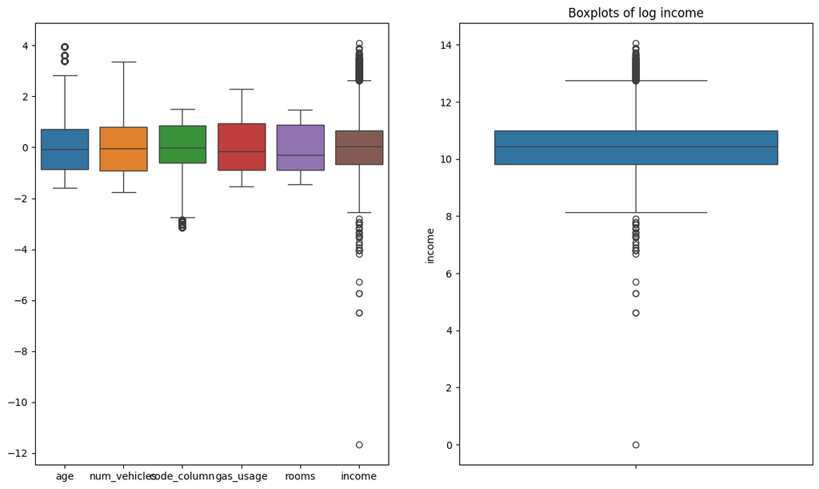

```python
fig, axs = plt.subplots(1, 2, figsize=(14, 8))
sns.boxplot(data=df_normalizado[valores_a_normalizar], ax=axs[0])
plt.title("Boxplots of Customer Dataset Features")
plt.xticks(rotation=90)

sns.boxplot(data=df['income'], ax=axs[1])
plt.title("Boxplots of log income")
plt.xticks(rotation=90)
```

```python
df_normalizado['income'].kurtosis()
```

```
0.21961194233811066
```

```python
df_outliers = pd.DataFrame()
for coluna in valores_a_normalizar:
    Q1 = df_normalizado[coluna].quantile(0.25)
    Q3 = df_normalizado[coluna].quantile(0.75)
    IQR = Q3 - Q1
    limite_inferior = Q1 - 1.5 * IQR
    limite_superior = Q3 + 1.5 * IQR
    outliers = df_normalizado[(df_normalizado[coluna] < limite_inferior) | (df_normalizado[coluna] > limite_superior)]
    df_outliers = pd.concat([df_outliers, outliers])

df_outliers = df_outliers.drop_duplicates()
health_ins_zeros_outliers = df_outliers['health_ins'].value_counts().get(False, 0)
total_rows_outliers = df_outliers.shape[0]

if total_rows_outliers > 0:
    percentage_health_ins_zero = (health_ins_zeros_outliers / total_rows_outliers) * 100
else:
    percentage_health_ins_zero = 0

print('Percentage of no health insurance in the outliers values:', percentage_health_ins_zero)
print('No health insurance in the outliers values:', health_ins_zeros_outliers)
```

```
Percentage of no health insurance in the outliers values: 6.158730158730159
No health insurance in the outliers values: 97
```

```python
df_no_outliers = df_normalizado.copy()
for coluna in valores_a_normalizar:
    Q1 = df_normalizado[coluna].quantile(0.25)
    Q3 = df_normalizado[coluna].quantile(0.75)
    IQR = Q3 - Q1
    limite_inferior = Q1 - 1.5 * IQR
    limite_superior = Q3 + 1.5 * IQR
    df_no_outliers = df_no_outliers[(df_no_outliers[coluna] >= limite_inferior) & (df_no_outliers[coluna] <= limite_superior)]

df_no_outliers.shape
```

```
(69120, 14)
```

```python
df.shape[0]-df_no_outliers.shape[0]
```

```
1575
```

Next we apply one-hot-encoding to all categorical columns since it is easier to work with. The columns 'Unnamed: 0' and 'custid' don't explain the relations in the data so we can remove them.

```python
categorical_columns = ['marital_status', 'housing_type', 'state_of_res']
df_encoded = pd.get_dummies(df_normalizado, columns=categorical_columns, drop_first=False)

rename_mapping = {
    col: col.replace('state_of_res_', '').replace('marital_status_', '').replace('housing_type_', '')
    for col in df_encoded.columns
    if col.startswith('state_of_res_') or col.startswith('marital_status_') or col.startswith('housing_type_')
}
rename_mapping.update({
    'is_employed_True': 'employed',
    'is_employed_False': 'unemployed'
})
df_encoded = df_encoded.rename(columns=rename_mapping)

print(df_encoded.columns)

features_to_encode = [
    'sex', 'health_ins', 'recent_move_b', 'employed', 'unemployed'
] + list(rename_mapping.values())

label_encoder = LabelEncoder()
for feature in features_to_encode:
    if feature in df_encoded.columns:
        df_encoded[feature] = label_encoder.fit_transform(df_encoded[feature])

display(df_encoded)
```

```
Index(['sex', 'income', 'health_ins', 'num_vehicles', 'age', 'code_column',
       'gas_usage', 'rooms', 'recent_move_b', 'unemployed', 'employed',
       'Divorced/Separated', 'Married', 'Never married', 'Widowed',
       'Homeowner free and clear', 'Homeowner with mortgage/loan',
       'Occupied with no rent', 'Rented', 'Alabama', 'Alaska', 'Arizona',
       'Arkansas', 'California', 'Colorado', 'Connecticut', 'Delaware',
       'District of Columbia', 'Florida', 'Georgia', 'Hawaii', 'Idaho',
       'Illinois', 'Indiana', 'Iowa', 'Kansas', 'Kentucky', 'Louisiana',
       'Maine', 'Maryland', 'Massachusetts', 'Michigan', 'Minnesota',
       'Mississippi', 'Missouri', 'Montana', 'Nebraska', 'Nevada',
       'New Hampshire', 'New Jersey', 'New Mexico', 'New York',
       'North Carolina', 'North Dakota', 'Ohio', 'Oklahoma', 'Oregon',
       'Pennsylvania', 'Rhode Island', 'South Carolina', 'South Dakota',
       'Tennessee', 'Texas', 'Utah', 'Vermont', 'Virginia', 'Washington',
       'West Virginia', 'Wisconsin', 'Wyoming'],
      dtype='object')
```

|  | sex | income | health_ins | num_vehicles | age | code_column | gas_usage | rooms | recent_move_b | unemployed | ... | South Dakota | Tennessee | Texas | Utah | Vermont | Virginia | Washington | West Virginia | Wisconsin | Wyoming |
| --- | --- | --- | --- | --- | --- | --- | --- | --- | --- | --- | --- | --- | --- | --- | --- | --- | --- | --- | --- | --- | --- |
| 0 | 1 | -0.148600 | 1 | -1.766401 | -1.413978 | -0.860877 | 1.693532 | -0.290099 | 0 | 0 | ... | 0 | 0 | 0 | 0 | 0 | 0 | 0 | 0 | 0 | 0 |
| 1 | 0 | -0.102960 | 1 | -1.766401 | 1.831783 | -0.860877 | -0.875725 | 1.467825 | 1 | 0 | ... | 0 | 0 | 0 | 0 | 0 | 0 | 0 | 0 | 0 | 0 |
| 2 | 0 | -0.188104 | 1 | -0.057250 | -1.022248 | -0.860877 | 0.690727 | -0.290099 | 0 | 0 | ... | 0 | 0 | 0 | 0 | 0 | 0 | 0 | 0 | 0 | 0 |
| 3 | 0 | 0.339907 | 1 | -0.911825 | 2.447359 | -0.860877 | 1.355107 | -0.876073 | 0 | 0 | ... | 0 | 0 | 0 | 0 | 0 | 0 | 0 | 0 | 0 | 0 |
| 4 | 1 | 0.370379 | 1 | -0.057250 | 0.992362 | -0.860877 | -0.875725 | -0.876073 | 0 | 0 | ... | 0 | 0 | 0 | 0 | 0 | 0 | 0 | 0 | 0 | 0 |
| ... | ... | ... | ... | ... | ... | ... | ... | ... | ... | ... | ... | ... | ... | ... | ... | ... | ... | ... | ... | ... | ... |
| 72452 | 0 | 1.149193 | 1 | -0.057250 | -0.966287 | -3.141591 | 1.029152 | 0.881851 | 0 | 0 | ... | 0 | 0 | 0 | 0 | 0 | 0 | 0 | 0 | 0 | 1 |
| 72453 | 0 | -0.293416 | 0 | -0.911825 | -1.358016 | -3.141591 | -0.147628 | 0.295876 | 0 | 0 | ... | 0 | 0 | 0 | 0 | 0 | 0 | 0 | 0 | 0 | 1 |
| 72454 | 0 | -0.196174 | 1 | -0.911825 | 2.055629 | -3.141591 | 1.355107 | 1.467825 | 0 | 0 | ... | 0 | 0 | 0 | 0 | 0 | 0 | 0 | 0 | 0 | 1 |
| 72455 | 1 | 1.019956 | 1 | -0.057250 | 0.041019 | -3.141591 | 1.181133 | -0.290099 | 0 | 0 | ... | 0 | 0 | 0 | 0 | 0 | 0 | 0 | 0 | 0 | 1 |
| 72456 | 0 | -0.140863 | 0 | -0.911825 | 0.656594 | -3.141591 | 0.825672 | 1.467825 | 0 | 0 | ... | 0 | 0 | 0 | 0 | 0 | 0 | 0 | 0 | 0 | 1 |

70695 rows × 70 columns

```python
coluna_a_mover = df_encoded.pop('health_ins')
df_encoded.insert(df_encoded.shape[1], 'health_ins', coluna_a_mover)
df_encoded.head()
```

|  | sex | income | num_vehicles | age | code_column | gas_usage | rooms | recent_move_b | unemployed | employed | ... | Tennessee | Texas | Utah | Vermont | Virginia | Washington | West Virginia | Wisconsin | Wyoming | health_ins |
| --- | --- | --- | --- | --- | --- | --- | --- | --- | --- | --- | --- | --- | --- | --- | --- | --- | --- | --- | --- | --- | --- |
| 0 | 1 | -0.148600 | -1.766401 | -1.413978 | -0.860877 | 1.693532 | -0.290099 | 0 | 0 | 1 | ... | 0 | 0 | 0 | 0 | 0 | 0 | 0 | 0 | 0 | 1 |
| 1 | 0 | -0.102960 | -1.766401 | 1.831783 | -0.860877 | -0.875725 | 1.467825 | 1 | 0 | 0 | ... | 0 | 0 | 0 | 0 | 0 | 0 | 0 | 0 | 0 | 1 |
| 2 | 0 | -0.188104 | -0.057250 | -1.022248 | -0.860877 | 0.690727 | -0.290099 | 0 | 0 | 1 | ... | 0 | 0 | 0 | 0 | 0 | 0 | 0 | 0 | 0 | 1 |
| 3 | 0 | 0.339907 | -0.911825 | 2.447359 | -0.860877 | 1.355107 | -0.876073 | 0 | 0 | 0 | ... | 0 | 0 | 0 | 0 | 0 | 0 | 0 | 0 | 0 | 1 |
| 4 | 1 | 0.370379 | -0.057250 | 0.992362 | -0.860877 | -0.875725 | -0.876073 | 0 | 0 | 1 | ... | 0 | 0 | 0 | 0 | 0 | 0 | 0 | 0 | 0 | 1 |

5 rows × 70 columns

For logistic purposes, we changed the variables name to be more intuitive and readable and moved 'health_ins' column to the end because is the one we want to predict.

Now we are going to see which variables have a correlation higher than 60%.

```python
for i in range(len(df_encoded.columns)):
    for j in range(i+1,len(df_encoded.columns)):
        if abs(df_encoded.corr().iloc[i,j]) > 0.6 and i!=j:
            print('correlation between: ',df_encoded.columns[i],' and ', df_encoded.columns[j],' is ',df_encoded.corr().iloc[i,j])
```

```
correlation between:  Married  and  Never married  is  -0.6293502748555924
```

No pair of columns has correlation enough to remove any variable without losing information. Additionally, we will see the correlation between each variable and the last column ('health_ins') in order to see if exists any leaky feature.

```python
pd.set_option('display.max_rows', None)
correlations = df_encoded.corr()['health_ins'].drop('health_ins')
print(correlations)
pd.reset_option('display.max_rows')
```

```
sex                            -0.047005
income                          0.182827
num_vehicles                    0.036522
age                             0.165691
code_column                    -0.032136
gas_usage                       0.051480
rooms                          -0.005972
recent_move_b                  -0.058841
unemployed                     -0.100308
employed                       -0.010220
Divorced/Separated             -0.028781
Married                         0.100854
Never married                  -0.122583
Widowed                         0.054952
Homeowner free and clear        0.044242
Homeowner with mortgage/loan    0.107790
Occupied with no rent          -0.029985
Rented                         -0.148068
Alabama                        -0.005773
Alaska                         -0.017484
Arizona                        -0.000221
Arkansas                        0.003915
California                      0.012740
Colorado                        0.006642
Connecticut                     0.016365
Delaware                        0.003430
District of Columbia            0.007890
Florida                        -0.039613
Georgia                        -0.031279
Hawaii                          0.016344
Idaho                          -0.002498
Illinois                        0.014671
Indiana                         0.000061
Iowa                            0.015552
Kansas                          0.001933
Kentucky                        0.011250
Louisiana                      -0.012396
Maine                           0.002573
Maryland                        0.011579
Massachusetts                   0.032311
```

[output cut: 15 more lines]

```
Oregon                          0.006340
Pennsylvania                    0.024041
Rhode Island                    0.010383
South Carolina                 -0.008707
South Dakota                   -0.005700
Tennessee                      -0.003092
Texas                          -0.081981
Utah                            0.002464
Vermont                         0.009797
Virginia                        0.001484
Washington                      0.013382
West Virginia                   0.011448
Wisconsin                       0.019454
Wyoming                        -0.004126
Name: health_ins, dtype: float64
```

We conclude there are no leaky feature. Now we verify if exists any column without variance and in that case we remove it.

```python
colunas_sem_variancia = []
for coluna in df_encoded.columns:
    if df_encoded[coluna].var() == 0:
        colunas_sem_variancia.append(coluna)
print(colunas_sem_variancia)
```

```
[]
```

All columns have variance. Now, after we finished the preprocessing, our dataset consists of 70695 rows and 70 coluns

# Modelos machine learning

To prepare data for training we start by doing a 80-20 split. This means models will train on 80% of the data and test on 20%.

```python
X = df_encoded.drop('health_ins', axis=1)
y = df_encoded['health_ins']

X_train, X_test, y_train, y_test = train_test_split(X, y, test_size=0.2, random_state=42)

algorithm_results = []
algo_reports = []
roc_auc_scores = []
```

Our modeling process evolved through 3 mainly stages:

- Inicially, we tested the models without SMOTE or grid-search leading to poorly results.
- Then, we incorporated grid search to identify the optimal combination of hyperparameters for our machine learning models
- Finally, we integrated SMOTE (Synthetic Minority Oversampling Technique) to generate synthetic samples for the minority class, enhancing model performance.

On each model we present two confusion matrices: "test data" (evaluates the model's performance on the heald-out test set) and "cross-validation" (evaluates the model's performance using cross-validation predictions over the entire dataset).

## Logistic Regresssion

The results from the first Logistic Regression used, without SMOTE or Grid-search were:

**Classification Report:**

| Class | Precision | Recall | F1-Score | Support |
| --- | --- | --- | --- | --- |
| 0 | 0.42 | 0.03 | 0.06 | 1299 |
| 1 | 0.91 | 1.00 | 0.95 | 12840 |

**Overall Metrics:**

- **Accuracy:** 0.91
- **Macro Average:**
  - Precision: 0.66
  - Recall: 0.51
  - F1-Score: 0.51
- **Weighted Average:**
  - Precision: 0.87
  - Recall: 0.91
  - F1-Score: 0.87

## Logistic Regresssion (with grid-search)

```python
param_grid = {
    'C': [0.01, 0.1, 1, 10, 100],
    'penalty': ['l1', 'l2']
}


logistic_model = LogisticRegression(max_iter=1000, random_state=20)

grid_search = GridSearchCV(estimator=logistic_model, param_grid=param_grid, cv=5, scoring='accuracy')

grid_search.fit(X_train, y_train)

best_logistic_model = grid_search.best_estimator_
best_params = grid_search.best_params_


print("Best parameters:", best_params)
print("Best Cross-Validation Accuracy:", grid_search.best_score_)

cv_predictions = cross_val_predict(best_logistic_model, X, y, cv=5)

y_pred= best_logistic_model.predict(X_test)

print("\nConfusion Matrix (Aggregated over folds):")
print(confusion_matrix(y, cv_predictions))

print("\nClassification Report (Aggregated over folds):")
print(classification_report(y, cv_predictions))
```

```
Best parameters: {'C': 0.01, 'penalty': 'l2'}
Best Cross-Validation Accuracy: 0.9087629911651762

Confusion Matrix (Aggregated over folds):
[[  183  6248]
 [  565 63699]]

Classification Report (Aggregated over folds):
              precision    recall  f1-score   support

           0       0.24      0.03      0.05      6431
           1       0.91      0.99      0.95     64264

    accuracy                           0.90     70695
   macro avg       0.58      0.51      0.50     70695
weighted avg       0.85      0.90      0.87     70695
```

## Logistic regression (with smote, grid-search and balanced)

```python
smote = SMOTE(random_state=42)
X_resampled, y_resampled = smote.fit_resample(X, y)
print("Resampled dataset distribution:", Counter(y_resampled))

X_train, X_test, y_train, y_test = train_test_split(X_resampled, y_resampled, test_size=0.3, random_state=42)

param_grid = {
    'classifier__C': [0.01, 0.1, 1, 10, 100],
    'classifier__penalty': ['l1', 'l2']
}

logistic_model = LogisticRegression(max_iter=1000, random_state=42, solver='liblinear', class_weight='balanced')

pipeline = Pipeline([
    ('classifier', logistic_model)
])

grid_search = GridSearchCV(
    estimator=pipeline,
    param_grid=param_grid,
    cv=5,
    scoring='accuracy'
)

grid_search.fit(X_train, y_train)

best_pipeline_lr = grid_search.best_estimator_
best_params = grid_search.best_params_

print("Best parameters:", best_params)
print("Best Cross-Validation Accuracy:", grid_search.best_score_)

y_pred = best_pipeline_lr.predict(X_test)
print("\nConfusion Matrix (Test Data):")
print(confusion_matrix(y_test, y_pred))

print("\nClassification Report (Test Data):")
print(classification_report(y_test,y_pred))

cv_predictions = cross_val_predict(
    best_pipeline_lr,
    X_resampled,
    y_resampled,
    cv=StratifiedKFold(n_splits=5, shuffle=True, random_state=42)
)

print("\nConfusion Matrix (Aggregated over folds):")
print(confusion_matrix(y_resampled, cv_predictions))

print("\nClassification Report (Aggregated over folds):")
print(classification_report(y_resampled, cv_predictions))
```

```
Resampled dataset distribution: Counter({1: 64264, 0: 64264})
Best parameters: {'classifier__C': 100, 'classifier__penalty': 'l1'}
Best Cross-Validation Accuracy: 0.826117884222089

Confusion Matrix (Test Data):
[[15461  3753]
 [ 2972 16373]]

Classification Report (Test Data):
              precision    recall  f1-score   support

           0       0.84      0.80      0.82     19214
           1       0.81      0.85      0.83     19345

    accuracy                           0.83     38559
   macro avg       0.83      0.83      0.83     38559
weighted avg       0.83      0.83      0.83     38559


Confusion Matrix (Aggregated over folds):
[[51758 12506]
 [ 9847 54417]]

Classification Report (Aggregated over folds):
              precision    recall  f1-score   support

           0       0.84      0.81      0.82     64264
           1       0.81      0.85      0.83     64264

    accuracy                           0.83    128528
   macro avg       0.83      0.83      0.83    128528
weighted avg       0.83      0.83      0.83    128528
```

ROC Curve:

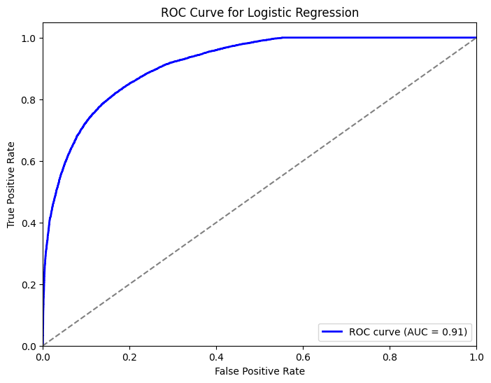

```python
y_probs = best_pipeline_lr.predict_proba(X_test)[:, 1]

auc = roc_auc_score(y_test, y_probs)
fpr, tpr, _ = roc_curve(y_test, y_probs)

plt.figure(figsize=(8, 6))
plt.plot(fpr, tpr, color='blue', lw=2, label='ROC curve (AUC = %0.2f)' % auc)
plt.plot([0, 1], [0, 1], color='gray', linestyle='--')
plt.xlim([0.0, 1.0])
plt.ylim([0.0, 1.05])
plt.xlabel('False Positive Rate')
plt.ylabel('True Positive Rate')
plt.title('ROC Curve for Logistic Regression')
plt.legend(loc="lower right")
plt.show()
```

Confusion Matrix:

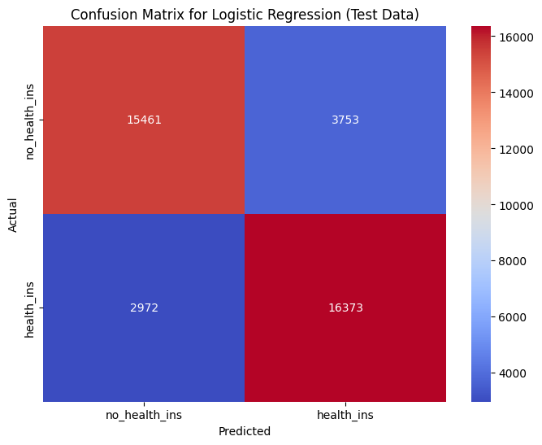

```python
cm_test = confusion_matrix(y_test, y_pred)

plt.figure(figsize=(8, 6))
sns.heatmap(cm_test, annot=True, fmt='d', cmap='coolwarm',
            xticklabels=['no_health_ins', 'health_ins'], yticklabels=['no_health_ins', 'health_ins'])
plt.xlabel('Predicted')
plt.ylabel('Actual')
plt.title('Confusion Matrix for Logistic Regression (Test Data)')
plt.show()
```

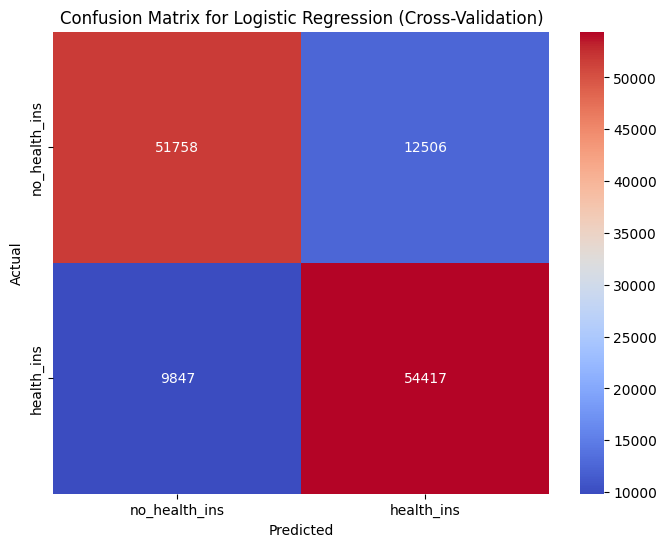

```python
cm_cv = confusion_matrix(y_resampled, cv_predictions)

plt.figure(figsize=(8, 6))
sns.heatmap(cm_cv, annot=True, fmt='d', cmap='coolwarm',
            xticklabels=['no_health_ins', 'health_ins'], yticklabels=['no_health_ins', 'health_ins'])
plt.xlabel('Predicted')
plt.ylabel('Actual')
plt.title('Confusion Matrix for Logistic Regression (Cross-Validation)')
plt.show()
```

## Decision Tree

The results from the first Decision Tree used, without SMOTE or Grid-search were:

**Classification Report:**

| Class | Precision | Recall | F1-Score | Support |
| --- | --- | --- | --- | --- |
| 0 | 0.23 | 0.25 | 0.24 | 1299 |
| 1 | 0.92 | 0.92 | 0.92 | 12840 |

**Overall Metrics:**

- **Accuracy:** 0.85
- **Macro Average:**
  - Precision: 0.58
  - Recall: 0.58
  - F1-Score: 0.58
- **Weighted Average:**
  - Precision: 0.86
  - Recall: 0.85
  - F1-Score: 0.86

## Decision Tree (with grid-search)

```python
param_grid = {
    'max_depth': [None, 3, 10, 15],
    'min_samples_split': [ 5, 10, 15],
    'min_samples_leaf': [ 2, 4, 6]
}

model = DecisionTreeClassifier(random_state=20)

grid_search = GridSearchCV(estimator=model, param_grid=param_grid, cv=5, scoring='accuracy')

grid_search.fit(X_train, y_train)

best_decision_model = grid_search.best_estimator_
best_params = grid_search.best_params_

print("Best Parameters:", best_params)

y_pred = best_decision_model.predict(X_test)

cv_scores = cross_val_score(best_decision_model, X, y, cv=5, scoring='accuracy')
cv_predictions = cross_val_predict(best_decision_model, X, y, cv=5)

print("Cross-Validation Accuracy Scores:", cv_scores)
print("Mean Cross-Validation Accuracy:", cv_scores.mean())

print("\nConfusion Matrix (Aggregated over folds):")
print(confusion_matrix(y, cv_predictions))

print("\nClassification Report (Aggregated over folds):")
print(classification_report(y, cv_predictions))
```

```
Best Parameters: {'max_depth': None, 'min_samples_leaf': 2, 'min_samples_split': 5}
Cross-Validation Accuracy Scores: [0.81130207 0.66546432 0.87057076 0.79192305 0.55994059]
Mean Cross-Validation Accuracy: 0.7398401584270458

Confusion Matrix (Aggregated over folds):
[[ 2332  4099]
 [14293 49971]]

Classification Report (Aggregated over folds):
              precision    recall  f1-score   support

           0       0.14      0.36      0.20      6431
           1       0.92      0.78      0.84     64264

    accuracy                           0.74     70695
   macro avg       0.53      0.57      0.52     70695
weighted avg       0.85      0.74      0.79     70695
```

## Decision Tree (with smote, grid-search and balanced)

```python
smote = SMOTE(random_state=42)
X_resampled, y_resampled = smote.fit_resample(X, y)
print("Resampled dataset distribution:", Counter(y_resampled))

X_train, X_test, y_train, y_test = train_test_split(X_resampled, y_resampled, test_size=0.3, random_state=42)

param_grid = {
    'classifier__max_depth': [None, 3, 10, 15],
    'classifier__min_samples_split': [5, 10, 15],
    'classifier__min_samples_leaf': [2, 4, 6]
}

model_dt = DecisionTreeClassifier(random_state=42, class_weight='balanced')
pipeline_dt = Pipeline([
    ('classifier', model_dt)
])

grid_search_dt = GridSearchCV(
    estimator=pipeline_dt,
    param_grid=param_grid,
    cv=5,
    scoring='accuracy'
)

grid_search_dt.fit(X_train, y_train)

best_pipeline_dt = grid_search_dt.best_estimator_
best_params_dt = grid_search_dt.best_params_

print("Best Parameters for Decision Tree:", best_params_dt)

y_pred_dt = best_pipeline_dt.predict(X_test)

cv_dt = StratifiedKFold(n_splits=5, shuffle=True, random_state=20)
cv_scores_dt = cross_val_score(best_pipeline_dt, X_resampled, y_resampled, cv=cv_dt, scoring='accuracy')
cv_predictions_dt = cross_val_predict(best_pipeline_dt, X_resampled, y_resampled, cv=cv_dt)

print("Decision Tree Cross-Validation Accuracy Scores:", cv_scores_dt)
print("Mean Cross-Validation Accuracy for Decision Tree:", cv_scores_dt.mean())

print("\nConfusion Matrix (Aggregated over folds) - Decision Tree:")
print(confusion_matrix(y_resampled, cv_predictions_dt))

print("\nClassification Report (Aggregated over folds) - Decision Tree:")
print(classification_report(y_resampled, cv_predictions_dt))

print("\nConfusion Matrix (Test Data) - Decision Tree:")
print(confusion_matrix(y_test, y_pred_dt))

print("\nClassification Report (Test Data) - Decision Tree:")
print(classification_report(y_test, y_pred_dt))
```

```
Resampled dataset distribution: Counter({1: 64264, 0: 64264})
Best Parameters for Decision Tree: {'classifier__max_depth': None, 'classifier__min_samples_leaf': 2, 'classifier__min_samples_split': 5}
Decision Tree Cross-Validation Accuracy Scores: [0.87003034 0.87469851 0.87578775 0.87768917 0.87593853]
Mean Cross-Validation Accuracy for Decision Tree: 0.8748288619598451

Confusion Matrix (Aggregated over folds) - Decision Tree:
[[57504  6760]
 [ 9328 54936]]

Classification Report (Aggregated over folds) - Decision Tree:
              precision    recall  f1-score   support

           0       0.86      0.89      0.88     64264
           1       0.89      0.85      0.87     64264

    accuracy                           0.87    128528
   macro avg       0.88      0.87      0.87    128528
weighted avg       0.88      0.87      0.87    128528


Confusion Matrix (Test Data) - Decision Tree:
[[16473  2741]
 [ 2233 17112]]

Classification Report (Test Data) - Decision Tree:
              precision    recall  f1-score   support

           0       0.88      0.86      0.87     19214
           1       0.86      0.88      0.87     19345

    accuracy                           0.87     38559
   macro avg       0.87      0.87      0.87     38559
weighted avg       0.87      0.87      0.87     38559
```

ROC Curve:

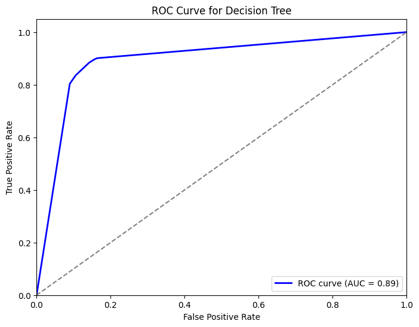

```python
y_probs = best_pipeline_dt.predict_proba(X_test)[:, 1]

fpr, tpr, _= roc_curve(y_test, y_probs)
auc = roc_auc_score(y_test, y_probs)

plt.figure(figsize=(8, 6))
plt.plot(fpr, tpr, color='blue', lw=2, label='ROC curve (AUC = %0.2f)' % auc)
plt.plot([0, 1], [0, 1], color='gray', linestyle='--')
plt.xlim([0.0, 1.0])
plt.ylim([0.0, 1.05])
plt.xlabel('False Positive Rate')
plt.ylabel('True Positive Rate')
plt.title('ROC Curve for Decision Tree')
plt.legend(loc="lower right")
plt.show()
```

Confusion Matrix:

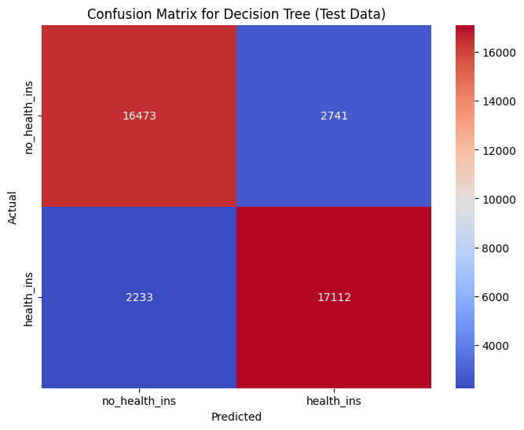

```python
cm_test_dt = confusion_matrix(y_test, y_pred_dt)

plt.figure(figsize=(8, 6))
sns.heatmap(cm_test_dt, annot=True, fmt='d', cmap='coolwarm',
            xticklabels=['no_health_ins', 'health_ins'], yticklabels=['no_health_ins', 'health_ins'])
plt.xlabel('Predicted')
plt.ylabel('Actual')
plt.title('Confusion Matrix for Decision Tree (Test Data)')
plt.show()
```

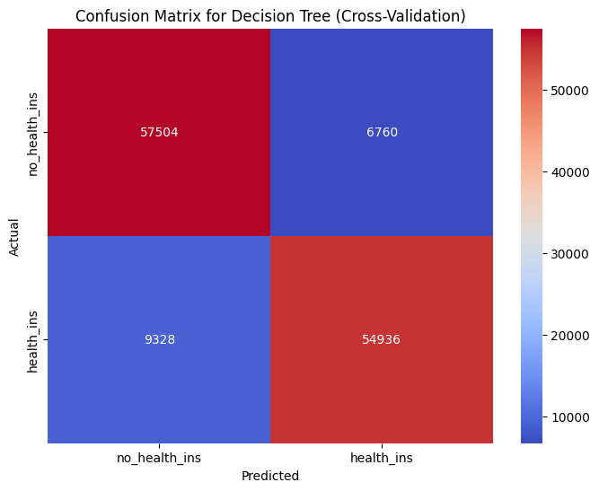

```python
cm_cv_dt = confusion_matrix(y_resampled, cv_predictions_dt)

plt.figure(figsize=(8, 6))
sns.heatmap(cm_cv_dt, annot=True, fmt='d', cmap='coolwarm',
            xticklabels=['no_health_ins', 'health_ins'], yticklabels=['no_health_ins', 'health_ins'])
plt.xlabel('Predicted')
plt.ylabel('Actual')
plt.title('Confusion Matrix for Decision Tree (Cross-Validation)')
plt.show()
```

## SVM

The results from the first SVM used without SMOTE or Grid-search were:

**Classification Report:**

| Class | Precision | Recall | F1-Score | Support |
| --- | --- | --- | --- | --- |
| 0 | 0.00 | 0.00 | 0.00 | 1299 |
| 1 | 0.91 | 1.00 | 0.95 | 12840 |

**Overall Metrics:**

- **Accuracy:** 0.91
- **Macro Average:**
  - Precision: 0.45
  - Recall: 0.50
  - F1-Score: 0.48
- **Weighted Average:**
  - Precision: 0.82
  - Recall: 0.91
  - F1-Score: 0.86

## SVM (with grid-search)

```python
scaler = StandardScaler()
scaler.fit(X_train)
X_train_scaled = scaler.fit_transform(X_train)
X_test_scaled = scaler.transform(X_test)

param_grid = {
    'C': [0.1, 1, 10],
    'gamma': ['scale', 'auto'],
    'kernel': ['rbf', 'sigmoid']
}

svm_model = SVC(max_iter=300)

grid_search = GridSearchCV(estimator=svm_model, param_grid=param_grid, cv=5, scoring='accuracy')

grid_search.fit(X_train_scaled, y_train)

best_svm_model = grid_search.best_estimator_
best_params = grid_search.best_params_

print("Best Parameters:", best_params)

y_pred = best_svm_model.predict(X_test_scaled)

cv_scores = cross_val_score(best_svm_model, X, y, cv=5, scoring='accuracy')
cv_predictions = cross_val_predict(best_svm_model, X, y, cv=5)

print("Cross-Validation Accuracy Scores:", cv_scores)
print("Mean Cross-Validation Accuracy:", cv_scores.mean())

print("\nConfusion Matrix (Aggregated over folds):")
print(confusion_matrix(y, cv_predictions))

print("\nClassification Report (Aggregated over folds):")
print(classification_report(y, cv_predictions))
```

```
Best Parameters: {'C': 10, 'gamma': 'auto', 'kernel': 'sigmoid'}
Cross-Validation Accuracy Scores: [0.77275621 0.9090459  0.90699484 0.90911663 0.5344791 ]
Mean Cross-Validation Accuracy: 0.8064785345498267

Confusion Matrix (Aggregated over folds):
[[  530  5901]
 [ 7780 56484]]

Classification Report (Aggregated over folds):
              precision    recall  f1-score   support

           0       0.06      0.08      0.07      6431
           1       0.91      0.88      0.89     64264

    accuracy                           0.81     70695
   macro avg       0.48      0.48      0.48     70695
weighted avg       0.83      0.81      0.82     70695
```

## SVM (with smote, grid-search and balanced)

```python
param_grid = {
    'classifier__C': [0.1, 1, 10],
    'classifier__gamma': ['scale', 'auto'],
    'classifier__kernel': ['rbf', 'sigmoid']
}

smote = SMOTE(random_state=42)
scaler = StandardScaler()
svm_model = SVC(max_iter=300, random_state=42, probability=True, class_weight='balanced')

pipeline = Pipeline([
    ('smote', smote),
    ('scaler', scaler),
    ('classifier', svm_model)
])

grid_search = GridSearchCV(
    estimator=pipeline,
    param_grid=param_grid,
    cv=5,
    scoring='accuracy',
    n_jobs=-1
)

grid_search.fit(X_train, y_train)

best_pipeline_svm = grid_search.best_estimator_
best_params = grid_search.best_params_

print("Best Parameters:", best_params)

y_pred = best_pipeline_svm.predict(X_test)

cv = StratifiedKFold(n_splits=5, shuffle=True, random_state=42)
cv_scores = cross_val_score(best_pipeline_svm, X, y, cv=cv, scoring='accuracy')
cv_predictions = cross_val_predict(best_pipeline_svm, X, y, cv=cv)

print("Cross-Validation Accuracy Scores:", cv_scores)
print("Mean Cross-Validation Accuracy:", cv_scores.mean())

print("\nConfusion Matrix (Aggregated over folds):")
print(confusion_matrix(y, cv_predictions))

print("\nClassification Report (Aggregated over folds):")
print(classification_report(y, cv_predictions))
```

```
Best Parameters: {'classifier__C': 1, 'classifier__gamma': 'scale', 'classifier__kernel': 'sigmoid'}
Cross-Validation Accuracy Scores: [0.69014782 0.59127237 0.50251079 0.53476201 0.45568994]
Mean Cross-Validation Accuracy: 0.5548765825022985

Confusion Matrix (Aggregated over folds):
[[ 3139  3292]
 [28176 36088]]

Classification Report (Aggregated over folds):
              precision    recall  f1-score   support

           0       0.10      0.49      0.17      6431
           1       0.92      0.56      0.70     64264

    accuracy                           0.55     70695
   macro avg       0.51      0.52      0.43     70695
weighted avg       0.84      0.55      0.65     70695
```

ROC Curve:

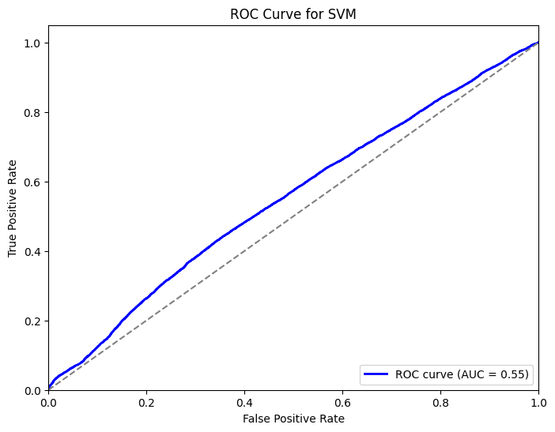

```python
y_probs = best_pipeline_svm.decision_function(X_test)

fpr, tpr, _ = roc_curve(y_test, y_probs)
auc = roc_auc_score(y_test, y_probs)

plt.figure(figsize=(8, 6))
plt.plot(fpr, tpr, color='blue', lw=2, label='ROC curve (AUC = %0.2f)' % auc)
plt.plot([0, 1], [0, 1], color='gray', linestyle='--')
plt.xlim([0.0, 1.0])
plt.ylim([0.0, 1.05])
plt.xlabel('False Positive Rate')
plt.ylabel('True Positive Rate')
plt.title('ROC Curve for SVM')
plt.legend(loc="lower right")
plt.show()
```

Confusion Matrix:

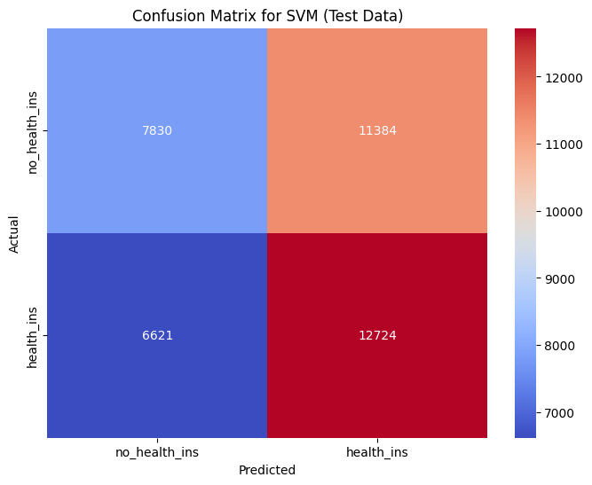

```python
cm_test_svm = confusion_matrix(y_test, y_pred)

plt.figure(figsize=(8, 6))
sns.heatmap(cm_test_svm, annot=True, fmt='d', cmap='coolwarm',
            xticklabels=['no_health_ins', 'health_ins'], yticklabels=['no_health_ins', 'health_ins'])
plt.xlabel('Predicted')
plt.ylabel('Actual')
plt.title('Confusion Matrix for SVM (Test Data)')
plt.show()
```

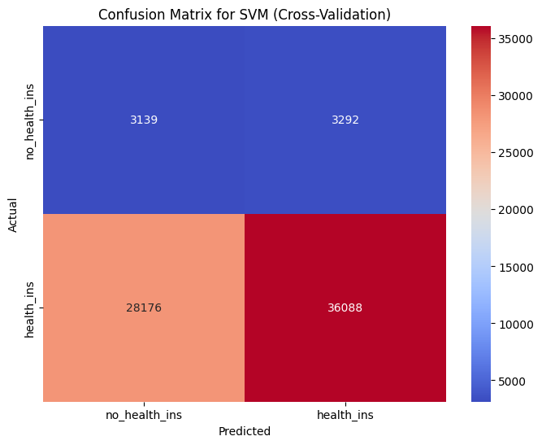

```python
cm_cv_svm = confusion_matrix(y, cv_predictions)

plt.figure(figsize=(8, 6))
sns.heatmap(cm_cv_svm, annot=True, fmt='d', cmap='coolwarm',
            xticklabels=['no_health_ins', 'health_ins'], yticklabels=['no_health_ins', 'health_ins'])
plt.xlabel('Predicted')
plt.ylabel('Actual')
plt.title('Confusion Matrix for SVM (Cross-Validation)')
plt.show()
```

## Random Forest

The results from the first Random Forest used, without SMOTE or Grid-search were:

**Classification Report:**

| Class | Precision | Recall | F1-Score | Support |
| --- | --- | --- | --- | --- |
| 0 | 0.41 | 0.06 | 0.10 | 1299 |
| 1 | 0.91 | 0.99 | 0.95 | 12840 |

**Overall Metrics:**

- **Accuracy:** 0.91
- **Macro Average:**
  - Precision: 0.66
  - Recall: 0.52
  - F1-Score: 0.52
- **Weighted Average:**
  - Precision: 0.87
  - Recall: 0.91
  - F1-Score: 0.87

## Random Forest (with grid-search)

```python
param_grid = {
    'n_estimators': [100, 200, 300],
    'max_depth': [10, 20, 30],
}

rf_classifier = RandomForestClassifier(random_state=20)

grid_search = GridSearchCV(rf_classifier, param_grid, cv=5, scoring='accuracy')

grid_search.fit(X_train, y_train)

best_rf_classifier = grid_search.best_estimator_
best_params = grid_search.best_params_

print("Best parameters:", best_params)

y_pred = best_rf_classifier.predict(X_test)

cv_scores = cross_val_score(best_rf_classifier, X, y, cv=5, scoring='accuracy')
cv_predictions = cross_val_predict(best_rf_classifier, X, y, cv=5)

print("Cross-Validation Accuracy Scores:", cv_scores)
print("Mean Cross-Validation Accuracy:", cv_scores.mean())

print("\nConfusion Matrix (Aggregated over folds):")
print(confusion_matrix(y, cv_predictions))

print("\nClassification Report (Aggregated over folds):")
print(classification_report(y, cv_predictions))
```

```
Best parameters: {'max_depth': 30, 'n_estimators': 200}
Cross-Validation Accuracy Scores: [0.90826791 0.64035646 0.90897518 0.86017399 0.52075819]
Mean Cross-Validation Accuracy: 0.7677063441544664

Confusion Matrix (Aggregated over folds):
[[ 1454  4977]
 [11445 52819]]

Classification Report (Aggregated over folds):
              precision    recall  f1-score   support

           0       0.11      0.23      0.15      6431
           1       0.91      0.82      0.87     64264

    accuracy                           0.77     70695
   macro avg       0.51      0.52      0.51     70695
weighted avg       0.84      0.77      0.80     70695
```

## Random Forest (with smote, grid-search and balanced)

```python
smote = SMOTE(random_state=42)
X_resampled, y_resampled = smote.fit_resample(X, y)
print("Resampled dataset distribution:", Counter(y_resampled))

X_train, X_test, y_train, y_test = train_test_split(X_resampled, y_resampled, test_size=0.3, random_state=42)

param_grid = {
    'classifier__n_estimators': [100, 200, 300],
    'classifier__max_depth': [10, 20, 30],
}

rf_classifier = RandomForestClassifier(random_state=42, class_weight='balanced')
pipeline = Pipeline([('classifier', rf_classifier)])

grid_search = GridSearchCV(pipeline, param_grid, cv=5, scoring='accuracy')

grid_search.fit(X_train, y_train)

best_pipeline_rf = grid_search.best_estimator_
best_params = grid_search.best_params_
print("Best parameters:", best_params)

y_pred = best_pipeline_rf.predict(X_test)

print("Confusion Matrix (Test Data):\n", confusion_matrix(y_test, y_pred))
print("\nClassification Report (Test Data):\n", classification_report(y_test, y_pred))

cv = StratifiedKFold(n_splits=5, shuffle=True, random_state=42)
cv_scores = cross_val_score(best_pipeline_rf, X_resampled, y_resampled, cv=cv, scoring='accuracy')
cv_predictions = cross_val_predict(best_pipeline_rf, X_resampled, y_resampled, cv=cv)

print("Cross-Validation Accuracy Scores:", cv_scores)
print("Mean Cross-Validation Accuracy:", cv_scores.mean())

print("\nConfusion Matrix (Aggregated over folds):")
print(confusion_matrix(y_resampled, cv_predictions))

print("\nClassification Report (Aggregated over folds):")
print(classification_report(y_resampled, cv_predictions))
```

```
Resampled dataset distribution: Counter({1: 64264, 0: 64264})
Best parameters: {'classifier__max_depth': 30, 'classifier__n_estimators': 300}
Confusion Matrix (Test Data):
 [[18312   902]
 [ 2122 17223]]

Classification Report (Test Data):
               precision    recall  f1-score   support

           0       0.90      0.95      0.92     19214
           1       0.95      0.89      0.92     19345

    accuracy                           0.92     38559
   macro avg       0.92      0.92      0.92     38559
weighted avg       0.92      0.92      0.92     38559

Cross-Validation Accuracy Scores: [0.92869369 0.9290827  0.92705983 0.92269986 0.92915775]
Mean Cross-Validation Accuracy: 0.9273387680511573

Confusion Matrix (Aggregated over folds):
[[61371  2893]
 [ 6446 57818]]

Classification Report (Aggregated over folds):
              precision    recall  f1-score   support

           0       0.90      0.95      0.93     64264
           1       0.95      0.90      0.93     64264

    accuracy                           0.93    128528
   macro avg       0.93      0.93      0.93    128528
weighted avg       0.93      0.93      0.93    128528
```

ROC Curve:

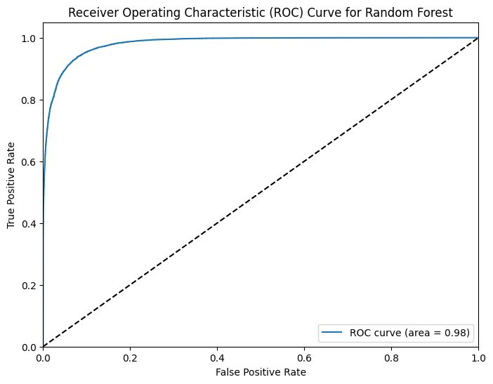

```python
y_probs = best_pipeline_rf.predict_proba(X_test)[:, 1]

auc_score = roc_auc_score(y_test, y_probs)
fpr, tpr, _ = roc_curve(y_test, y_probs)

plt.figure(figsize=(8, 6))
plt.plot(fpr, tpr, label='ROC curve (area = %0.2f)' % auc_score)
plt.plot([0, 1], [0, 1], 'k--')
plt.xlim([0.0, 1.0])
plt.ylim([0.0, 1.05])
plt.xlabel('False Positive Rate')
plt.ylabel('True Positive Rate')
plt.title('Receiver Operating Characteristic (ROC) Curve for Random Forest')
plt.legend(loc="lower right")
plt.show()
```

Confusion Matrix:

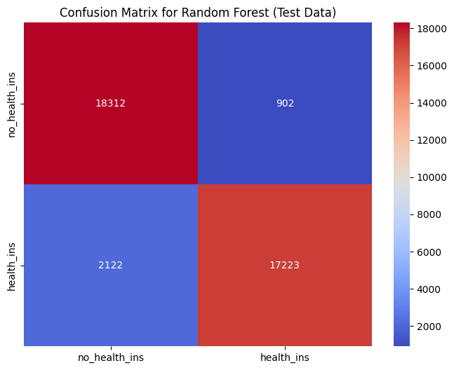

```python
cm_test_rf = confusion_matrix(y_test, y_pred)

plt.figure(figsize=(8, 6))
sns.heatmap(cm_test_rf, annot=True, fmt='d', cmap='coolwarm', xticklabels=['no_health_ins', 'health_ins'], yticklabels=['no_health_ins', 'health_ins'])
plt.title('Confusion Matrix for Random Forest (Test Data)')
plt.show()
```

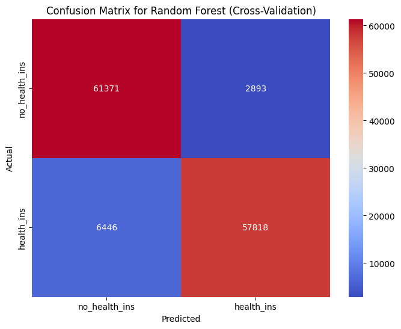

```python
cm_cv_rf = confusion_matrix(y_resampled, cv_predictions)
plt.figure(figsize=(8, 6))
sns.heatmap(cm_cv_rf, annot=True, fmt='d', cmap='coolwarm', xticklabels=['no_health_ins', 'health_ins'], yticklabels=['no_health_ins', 'health_ins'])
plt.xlabel('Predicted')
plt.ylabel('Actual')
plt.title('Confusion Matrix for Random Forest (Cross-Validation)')
plt.show()
```

## KNN

The results from the first KNN used, without SMOTE or Grid-search were:

**Classification Report:**

| Class | Precision | Recall | F1-Score | Support |
| --- | --- | --- | --- | --- |
| 0 | 0.35 | 0.09 | 0.14 | 1299 |
| 1 | 0.91 | 0.98 | 0.95 | 12840 |

**Overall Metrics:**

- **Accuracy:** 0.90
- **Macro Average:**
  - Precision: 0.63
  - Recall: 0.54
  - F1-Score: 0.55
- **Weighted Average:**
  - Precision: 0.86
  - Recall: 0.90
  - F1-Score: 0.87

## KNN (with grid-search)

```python
pipeline = Pipeline([
    ('scaler', StandardScaler()),
    ('knn', KNeighborsClassifier())
])

param_grid = {
    'knn__n_neighbors': [3, 5, 8, 10]
}

grid_search = GridSearchCV(estimator=pipeline, param_grid=param_grid, cv=5, scoring='accuracy', n_jobs=-1)
grid_search.fit(X, y)


print("Best Parameters:", grid_search.best_params_)
print("Best Cross-Validation Accuracy:", grid_search.best_score_)


best_model = grid_search.best_estimator_
cv_predictions = cross_val_predict(best_model, X, y, cv=5)

y_pred= best_model.predict(X_test)

print("\nConfusion Matrix (Aggregated over folds):")
print(confusion_matrix(y, cv_predictions))

print("\nClassification Report (Aggregated over folds):")
print(classification_report(y, cv_predictions))
```

```
Best Parameters: {'knn__n_neighbors': 10}
Best Cross-Validation Accuracy: 0.7413961383407596

Confusion Matrix (Aggregated over folds):
[[ 1683  4748]
 [13534 50730]]

Classification Report (Aggregated over folds):
              precision    recall  f1-score   support

           0       0.11      0.26      0.16      6431
           1       0.91      0.79      0.85     64264

    accuracy                           0.74     70695
   macro avg       0.51      0.53      0.50     70695
weighted avg       0.84      0.74      0.78     70695
```

## KNN (with smote, grid-search and balanced)

```python
smote = SMOTE(random_state=42)
X_resampled, y_resampled = smote.fit_resample(X, y)

print("Resampled dataset distribution:", Counter(y_resampled))

X_train, X_test, y_train, y_test = train_test_split(X_resampled, y_resampled, test_size=0.3, random_state=42)

pipeline = Pipeline([
    ('scaler', StandardScaler()),
    ('knn', KNeighborsClassifier())
])

param_grid = {
    'knn__n_neighbors': [3, 5, 8, 10],
    'knn__weights': ['uniform', 'distance']
}

grid_search = GridSearchCV(
    estimator=pipeline,
    param_grid=param_grid,
    cv=5,
    scoring='accuracy',
    n_jobs=-1
)

grid_search.fit(X_train, y_train)

print("Best Parameters:", grid_search.best_params_)
print("Best Cross-Validation Accuracy:", grid_search.best_score_)

best_model_knn = grid_search.best_estimator_

cv_predictions = cross_val_predict(best_model_knn, X_train, y_train, cv=5)

y_pred = best_model_knn.predict(X_test)

print("\nConfusion Matrix (Aggregated over folds):")
print(confusion_matrix(y_train, cv_predictions))

print("\nClassification Report (Aggregated over folds):")
print(classification_report(y_train, cv_predictions))

print("\nConfusion Matrix on Test Set:")
print(confusion_matrix(y_test, y_pred))

print("\nClassification Report on Test Set:")
print(classification_report(y_test, y_pred))
```

```
Resampled dataset distribution: Counter({1: 64264, 0: 64264})
Best Parameters: {'knn__n_neighbors': 3, 'knn__weights': 'distance'}
Best Cross-Validation Accuracy: 0.8973201698527727

Confusion Matrix (Aggregated over folds):
[[42918  2132]
 [ 7106 37813]]

Classification Report (Aggregated over folds):
              precision    recall  f1-score   support

           0       0.86      0.95      0.90     45050
           1       0.95      0.84      0.89     44919

    accuracy                           0.90     89969
   macro avg       0.90      0.90      0.90     89969
weighted avg       0.90      0.90      0.90     89969


Confusion Matrix on Test Set:
[[18440   774]
 [ 2777 16568]]

Classification Report on Test Set:
              precision    recall  f1-score   support

           0       0.87      0.96      0.91     19214
           1       0.96      0.86      0.90     19345

    accuracy                           0.91     38559
   macro avg       0.91      0.91      0.91     38559
weighted avg       0.91      0.91      0.91     38559
```

ROC Curve:

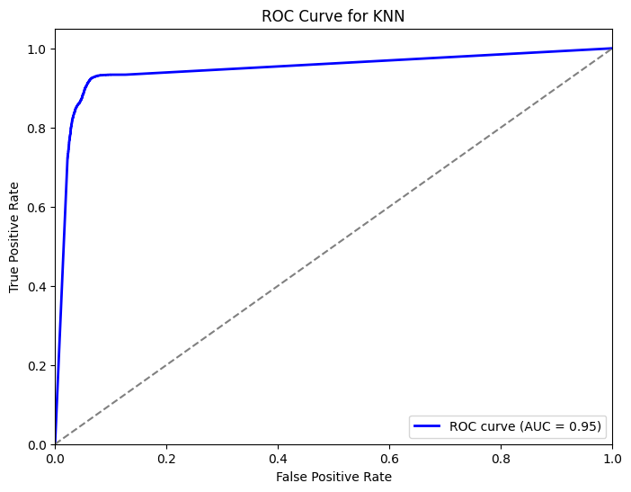

```python
y_probs = best_model_knn.predict_proba(X_test)[:, 1]


auc_score = roc_auc_score(y_test, y_probs)

fpr, tpr, _ = roc_curve(y_test, y_probs)


plt.figure(figsize=(8, 6))
plt.plot(fpr, tpr, color='blue', lw=2, label='ROC curve (AUC = %0.2f)' % auc_score)
plt.plot([0, 1], [0, 1], color='gray', linestyle='--')
plt.xlim([0.0, 1.0])
plt.ylim([0.0, 1.05])
plt.xlabel('False Positive Rate')
plt.ylabel('True Positive Rate')
plt.title('ROC Curve for KNN')
plt.legend(loc="lower right")
plt.show()
```

Confusion Matrix:

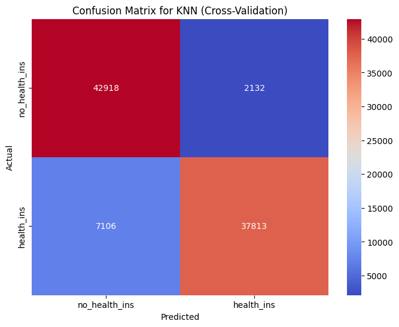

```python
cm_cv_knn = confusion_matrix(y_train, cv_predictions)

plt.figure(figsize=(8, 6))
sns.heatmap(cm_cv_knn, annot=True, fmt='d', cmap='coolwarm',
            xticklabels=['no_health_ins', 'health_ins'], yticklabels=['no_health_ins', 'health_ins'])
plt.xlabel('Predicted')
plt.ylabel('Actual')
plt.title('Confusion Matrix for KNN (Cross-Validation)')
plt.show()
```

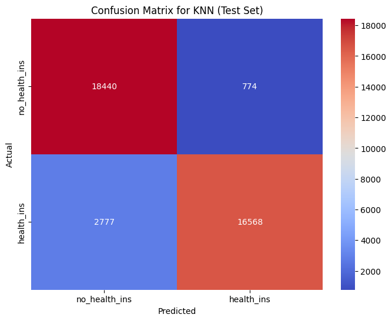

```python
cm_test_knn = confusion_matrix(y_test, y_pred)

plt.figure(figsize=(8, 6))
sns.heatmap(cm_test_knn, annot=True, fmt='d', cmap='coolwarm',
            xticklabels=['no_health_ins', 'health_ins'], yticklabels=['no_health_ins', 'health_ins'])
plt.xlabel('Predicted')
plt.ylabel('Actual')
plt.title('Confusion Matrix for KNN (Test Set)')
plt.show()
```

## Stacked Model (with smote, grid-search and balance)

```python
smote = SMOTE(random_state=42)
X_resampled, y_resampled = smote.fit_resample(X, y)
print("Resampled dataset distribution:", Counter(y_resampled))

X_train, X_test, y_train, y_test = train_test_split(X_resampled, y_resampled, test_size=0.3, random_state=42)

base_classifiers = [
    DecisionTreeClassifier(random_state=42),
    KNeighborsClassifier(),
    RandomForestClassifier(random_state=42)
]

stacking_clf = StackingClassifier(
    estimators=[
        ('decision_tree', DecisionTreeClassifier(random_state=42)),
        ('knn', KNeighborsClassifier()),
        ('random_forest', RandomForestClassifier(random_state=42))
    ],
    final_estimator=LogisticRegression(max_iter=100, random_state=42)
)

pipeline = Pipeline([
    ('scaler', StandardScaler()),
    ('stacking', stacking_clf)
])

kfold = KFold(n_splits=10, shuffle=True, random_state=42)
scores = cross_val_score(pipeline, X_train, y_train, scoring="roc_auc", cv=kfold)
print(f"{stacking_clf.__class__.__name__} ")
print(f"AUC: {scores.mean():.3f} STD: {scores.std():.2f}")

pipeline.fit(X_train, y_train)

cv_predictions = cross_val_predict(pipeline, X_train, y_train, cv=5)

y_pred = pipeline.predict(X_test)

print("\nConfusion Matrix (Aggregated over folds):")
print(confusion_matrix(y_train, cv_predictions))

print("\nClassification Report (Aggregated over folds):")
print(classification_report(y_train, cv_predictions))

print("\nConfusion Matrix on Test Set:")
print(confusion_matrix(y_test, y_pred))

print("\nClassification Report on Test Set:")
print(classification_report(y_test, y_pred))
```

```
Resampled dataset distribution: Counter({1: 64264, 0: 64264})
StackingClassifier
AUC: 0.986 STD: 0.00

Confusion Matrix (Aggregated over folds):
[[42303  2747]
 [ 2787 42132]]

Classification Report (Aggregated over folds):
              precision    recall  f1-score   support

           0       0.94      0.94      0.94     45050
           1       0.94      0.94      0.94     44919

    accuracy                           0.94     89969
   macro avg       0.94      0.94      0.94     89969
weighted avg       0.94      0.94      0.94     89969


Confusion Matrix on Test Set:
[[18121  1093]
 [ 1115 18230]]

Classification Report on Test Set:
              precision    recall  f1-score   support

           0       0.94      0.94      0.94     19214
           1       0.94      0.94      0.94     19345

    accuracy                           0.94     38559
   macro avg       0.94      0.94      0.94     38559
weighted avg       0.94      0.94      0.94     38559
```

ROC Curve:

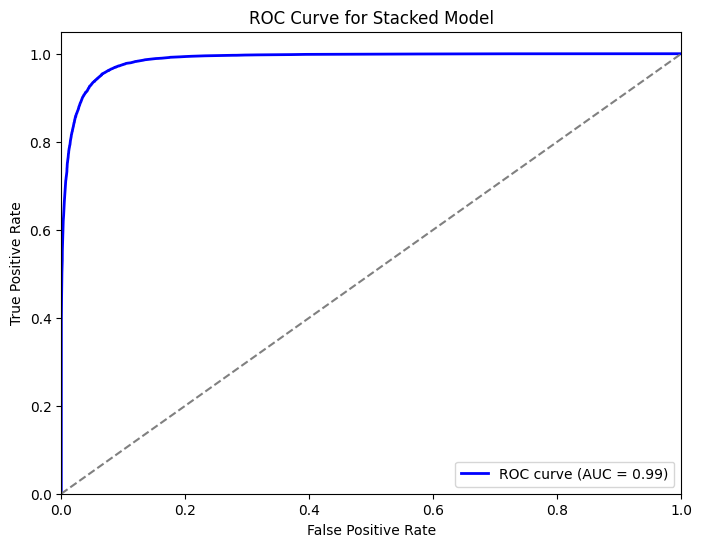

```python
y_probs = pipeline.predict_proba(X_test)[:, 1]


auc_score = roc_auc_score(y_test, y_probs)
fpr, tpr, _ = roc_curve(y_test, y_probs)


plt.figure(figsize=(8, 6))
plt.plot(fpr, tpr, color='blue', lw=2, label='ROC curve (AUC = %0.2f)' % auc_score)
plt.plot([0, 1], [0, 1], color='gray', linestyle='--')
plt.xlim([0.0, 1.0])
plt.ylim([0.0, 1.05])
plt.xlabel('False Positive Rate')
plt.ylabel('True Positive Rate')
plt.title('ROC Curve for Stacked Model')
plt.legend(loc="lower right")
plt.show()
```

Confusion Matrix:

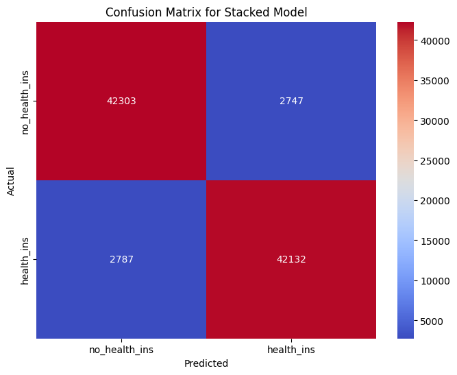

```python
cm = confusion_matrix(y_train, cv_predictions)


plt.figure(figsize=(8, 6))
sns.heatmap(cm, annot=True, fmt='d', cmap='coolwarm', xticklabels=['no_health_ins', 'health_ins'], yticklabels=['no_health_ins', 'health_ins'])
plt.xlabel('Predicted')
plt.ylabel('Actual')
plt.title('Confusion Matrix for Stacked Model')
plt.show()
```

# Conclusion

The results clearly demonstrate an improvement in performance across all models, except for the SVM. This can be attributed to SVM's inherent limitations with imbalanced datasets, as it prioritizes separating classes without accounting for their proportions. In contrast, the other models delivered strong results, with Random Forest emerging as the best performer due to its ability to aggregate predictions from multiple decision trees, effectively minimizing bias toward the majority class. Ultimately, we selected the three top-performing models (Decision Tree, Random Forest and KNN) and combined them into a stacked model, which achieved the best overall performance.